# Producing reproducible code: A DAA DS framework

**A note - 29JULY2022**

This document is an attempt at synthesising many disparate sources on doing reproducible data scientific work. Why this has been necessary is covered in the ‘Introduction’. To summarise my thoughts on producing reproducible work: shared principles that have been battle-tested by computer science, software engineering, etc, should form the bedrock of reproducible work in Data Science (version control, shared writing styles, reproducible environments) and additional ‘standards’ from other fields should also be included (package synthesis, assumption listing, minute keeping).

Following the principles of reproducible Data Science, this document is available on [GitHub](https://github.com/TL-Ingram/Reproducible_work) for Pull requests; it should be treated as a fluid document that will be updated, altered, and enhanced, as we improve our knowledge and practices as a team.

## Introduction

Data science is a burgeoning and yet still nascent field. Its popularity has created an influx of DS’ from an incredible array of disparate backgrounds; economics to biochemistry, and all fields in between! In fact, it’s quite likely that DS as a profession contains more generalist skilled individuals than any other scientific career, not least because of the variety of skills required to be proficient, but also due to the fields novelty - I think it reasonable to posit that most, current, established DS were either joining from a second career and/or received no formal pedagogy/taught themselves autodidacticly.

A generalist background clearly has merits, especially in the arena of data scientific work where a wide ranging skill set is absolutely necessary. However, the lack of pedagogical standardisation has caused problems with readability, reproducibility, and replicability. Interestingly, lacking pedagogical standardisation has not obviously inhibited the “output” of DS work from improving. Indeed, the widely recognised tools of Data Scientists’ (statistics, AI, coding, problem solving) have enjoyed rising competency and improvements, likely through a convergence in the lessons taught by both online and degree courses, and replicating pedagogy related to these skills from other disciplines.

However, how can we actually know that improvements in Data Scientists’ output have been accrued? A definition of improvements would be required, and is beyond this the scope of this brief piece, but I think it’s safe to assume that most definitions would include one or more of the following:

- more output (perhaps in a shorter timeframe),
- better performing models,
- more appropriate figures and statistical analyses.

But none of these determine whether the work that went into producing the output (data collection, datasets, the code), were appropriate for the question posed.

This is the crux of the matter: **the “correctness” of the output cannot be objectively assessed without transparency of the code.**

Formal courses on Data Science touch on reproducibility, however serious highlighting of the importance to practical Data Science appears to have been left to the individual to self-teach, or that they learn on-the-job. Here, I argue for reproducibility and describe a framework toward producing robust, reliable and reproducible work in the DAA Data Science team.

# Definitions: Reproducible and Replicable

Definitions of key terminology in this space is a real minefield, not least because the field you work in may determine the definition. For a full review on this topic, do read this peer-reviewed paper by [Hans Plesser (2018)](https://www.frontiersin.org/articles/10.3389/fninf.2017.00076/full).

The definitions I will be using are taken from the [Turing Way](https://the-turing-way.netlify.app/reproducible-research/overview/overview-definitions.html):

- *Reproducible*: A result is reproducible when the same analysis steps performed on the same dataset consistently produces the same answer.
- *Replicable*: A result is replicable when the same analysis performed on different datasets produces qualitatively similar answers.
- *Robust*: A result is robust when the same dataset is subjected to different analysis workflows to answer the same research question (for example one pipeline written in R and another written in Python) and a qualitatively similar or identical answer is produced. Robust results show that the work is not dependent on the specificities of the programming language chosen to perform the analysis.
- *Generalisable*: Combining replicable and robust findings allow us to form generalisable results. Note that running an analysis on a different software implementation and with a different dataset does not provide generalised results. There will be many more steps to know how well the work applies to all the different aspects of the research question. Generalisation is an important step towards understanding that the result is not dependent on a particular dataset nor a particular version of the analysis pipeline.

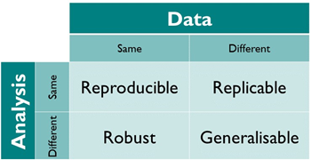

*How the Turing Way defines reproducible research*

# NHS data policy: highlighting reproducibility

Within the NHS, having dedicated Data Scientists’ (or even data literate Data Teams’) is a relatively nascent phenomenon. There is a tremendous amount of work to be done to bring NHS data standards up to that of private organisations. Encouragingly though, there’s definitely evidence that those with influence in the UK are advocating for the potential that Data Teams’ across the NHS can unlock.

The UK government has recently published NHS-centred documents that emphasise the importance, and give detailed guidance, on data best practices. Below are links pointing to these documents, which I’ll be keeping up-to-date when other relevant documents become available. It’s definitely worth reading these; they’re relevant to the work you do, but more importantly they will align you with the wider NHS data community.

- [Better, broader, safer: using health data for research and analysis - GOV.UK, April 2022](https://www.gov.uk/government/publications/better-broader-safer-using-health-data-for-research-and-analysis/better-broader-safer-using-health-data-for-research-and-analysis)
- [Data saves lives: reshaping health and social care with data - GOV.UK, June 2022](https://www.gov.uk/government/publications/data-saves-lives-reshaping-health-and-social-care-with-data/data-saves-lives-reshaping-health-and-social-care-with-data#how-you-can-get-involve)

# The DAA

Our department have published their three year plan, Caring For Our Data, 2022 - 2025 (download link below), which includes a section on Data Science. It is an encouraging document that promotes a bright vision for the Trust - you should read it. Unfortunately, reproducible working is not explicitly mentioned, so a revision would include greater emphasis on its necessity. However, there are certainly good examples of how working reproducibly will aid with some of the plans objectives:

**Working ethically**

*“…A key consideration within AI is ethics. Any Healthcare AI practice should put all patients and people first. This means that it is our responsibility to, for example, minimise representation bias within any of our algorithms.”* - Page 15.

- There are high-profile examples of published research that has been retracted due to code writing that did not adequately account for representation bias in their sample. Results can easily be misinterpreted when a sample set does not accurately represent your population.
- Writing code reproducibly allows others to review your work, gives visibility to any assumptions you’ve made, and keeps you accountable.
- Deep dives:

  – [Towards a Code of Ethics for AI](https://download.e-bookshelf.de/download/0010/4648/14/L-G-0010464814-0024159548.pdf) - Paula Boddington, 2017

**Transparent usage of data**

*“Improving the transparency of how data is (sic) used and shared”* - Page 16

- This dovetails nicely with working ethically. Transparency with our code keeps us accountable, makes code review possible, and therefore makes working unethically less likely to occur.
- Further than this, transparency of code forms the foundation of reproducible work. Full review of the methodology allows constructive critique and ensures appropriate methods and models were used.
- Transparency also fosters learning. Personally, I have primarily learned to code through forums, then reading scripts from others I work with, and more recently using GitHub to pull others repositories and explore their code. Transparent code is simply incredible for self-improvement.

**Data Quality**

*“Our people are confident their decisions are being made on robust data”* - Page 11

- If you’ve worked with data in the NHS then it shouldn’t shock you to hear me say how terrible the quality is: hand-typed fields, columns with different names but the same data, columns with impossible to understand values, impossible tails to distributions.. it goes on. A lot of our time is taken up with getting the data cleaned to an appropriate state for initial exploration.
- With so much pre-processing to do, it’s unlikely you’ll do a perfect job first time round. The issue then becomes whether you continue through to the “end” of your analysis without including/cleaning/excluding/factoring/etc - your output may well be correct for the data you used, but incorrect because the data you used was not appropriate. Working reproducibly will certainly help with this.
- In order to understand what you’ve done, writing code in a readable manner becomes a requirement. I’ll come on to writing styles later on, but suffice to say that a facet of reproducible work is readable work.

# DAA Data Science team: working reproducibly

Upholding the highest standards of data scientific work is what we will produce. In order to do that, we need to be aligned in the methods we will use daily to ensure reproducibility.

I’m now going to modify the Turing Way definition of ‘Reproducible’ to make it practically useful for our team’s daily work:

**Reproducible work necessitates ensuring that all code and all supporting information that went into producing an output is available, transparent, and readable.**

And for a more wordy definition I would add:

**All code iterations should be included and traceable using version control, which should be saved using appropriate project repositories that are available to the appropriate individuals. Additionally, all supporting information should similarly be saved in the project repository.**

Supporting information includes:

- Assumptions made during the analysis
- All meeting minutes with stakeholders, project managers, sponsors, etc
- Any additional non-code information or data that was relevant to the output

# Reproducibility checklist:

To make it as plain as possible, I’m going to start with a checklist of what I see are the major factors in ensuring reproducible work, before going into each in more detail.

- *Keep meeting minutes*
- *Environment*
- *Write down assumptions*
- *Writing style*
- *Source/version control*
- *Outputting work reproducibly*
- *Code testing*
- *Code review*
- *To_do list*

### Keep meeting minutes

Domain knowledge is vital. In our roles, we will usually be coming into a piece of work near the end of a process we may not have been involved in, in a mature workflow that has existed for years, or analysis of novel datasets for the sake of exploration. Unlike academia, where you may be involved in the development of the original hypothesis generation, data collection and onward analysis, here we will regularly take on the humbling role of a highly trained ignoramous! A separate topic is the Data Scientist attitude, but I’ll leave that for another time.

**Domain knowledge**

- Gaining domain knowledge is the priority for any new Data Science project.
- To begin, an initial meeting with key stakeholders, those working most intimately within the domain, should be prioritised. In our Trust, there are >150 databases in our SQL server.. just knowing which are relevant is tough without the stakeholders input.
- Further meetings at regular intervals should be put into the diary for follow-up questions.
- Push for shadowing or tours - first hand experience is of tremendous value.

**Meeting minutes**

- For your benefit: – Taking meeting minutes (shadow/tour minutes) should be ideally carried out during the experience or directly following it. – Evidence suggests we are poor at recall and are able to convince ourselves of falsities with total sincerity. Indeed, our working memory has only a limited capacity. Write things down ASAP. – Coming back to your minutes will have untold benefits to your project at all stages.
- For others benefit: – Without minutes, key domain knowledge will not be imparted to others trying to pick up your project, or understand the work. Nothing is as useful as the experiences themselves, but minutes are the minimum required for ensuring reproducibility between Data Scientists’.

**What should minutes include**

- Everything! They should be detailed enough to ensure your memory is refreshed by reading it a week after the meeting.
- Each meeting is different; it’s likely the initial stakeholder meeting will be more detailed than recurrent meetings.

**Practical purposes**

- **There is a meeting minutes template document in Teams.** This should be used to ensure standardisation across each of us and our projects.
- The template is located in: Teams -> Team - Data Science -> Projects -> Current -> Template_documents
- Each meeting minute document should be saved as “DDMONYYYY”. For example, 01JUL2022.
- The document should be saved within a “Meeting_minutes” folder within the appropriate project folder.
- Useful to describe the context. Ideally at the time as memory bad (eg how memory is bad? Papers on its unreliabilty?)
- Template document in Teams
- Create meeting minutes folder in each project. Save here. Save in format of “x.doc”

### Write down assumptions

I think this is often overlooked, but the number of assumptions you’ll make while working with a dataset are often large, and they may be more logical reasons, however someone else coming in to look at the data may not be able to decipher what you did without also understanding your assumptions.

As an example, let’s suppose we have a dataframe taken from a theatre admissions dataset that contains thousands of rows and hundreds of columns (this is common in the work we’re doing!). While cleaning it up, you notice that two of the columns, *closure* and *operation_end_time* have different headers but seem to contain the same values.

```
## # A tibble: 1,000 × 5
##    surgery_date_dt into_theatre incision closure operation_end_time
##    <date>          <chr>        <chr>    <chr>   <chr>
##  1 2022-01-06      10:50        11:24    14:44   14:44
##  2 2022-01-04      16:13        16:18    17:20   17:20
##  3 2022-01-04      10:46        10:48    11:20   11:20
##  4 2022-01-04      11:33        11:33    11:37   11:37
##  5 2022-01-04      11:00        11:14    11:38   11:38
##  6 2022-01-04      11:59        11:59    12:03   12:03
##  7 2022-01-04      15:53        15:58    16:27   16:27
##  8 2022-01-04      09:36        09:37    09:48   09:48
##  9 2022-01-04      12:02        12:05    12:18   12:18
## 10 2022-01-04      10:47        10:50    11:28   11:28
## # … with 990 more rows
```

You write a bit of code to test this and it turns out it’s true, all of them are the same!

```r
col_homogeneity_check <- figure_one %>%
  mutate(., check = if_else(closure == operation_end_time, TRUE, FALSE)) %>%
  group_by(., check, .drop = F) %>%
  summarise(., n = n()) %>%
  mutate(., freq = n/sum(n)) %>%
  print(.) # cols "closure" & "operation_end_time" are identical
```

```
## # A tibble: 1 × 3
##   check     n  freq
##   <lgl> <int> <dbl>
## 1 TRUE   1000     1
```

Although this may not seem like a classical example of an assumption, it’s still something that you assume to hold true in the future, so you would note this down as an assumption.

To make this reproducible, you would do the following:

1. Create a notepad file in your project folder titled “assumptions.txt”, and note this assumption. Describe the assumption, the test and result, and the actions taken. In this example: *assume closure == operation_end_time; test showed 100% identical; removed column “closure”, kept column “operation_end_time”*)
2. Comment out the test but do not delete.
3. Add a comment to the end of test to explain the test result in plain English.

A few other examples of assumptions:

- *assuming the meaning of a column*
- *assuming that two columns are collinear*
- *assuming that if column_one == x, then column_two == y*